# 03-exercises

Phil Li

April 20, 2016

## Readings

*APM*

- Chapter 4 “Over Fitting and Model Tuning”
- Chapter 12.2 “Logistic Regression”"

## Miscellaneous

I am still struggling with names …

- Please send me your picture
- [my photo here!](https://media.licdn.com/mpr/mpr/shrinknp_400_400/p/5/000/229/29f/3b94812.jpg)

## Assignment

Note: The following will set-up your environment for this exercise. If you get an error stating that the packages have not been found, you need to install those packages.

## StepAIC

Using Fuel Economy data set from the **AppliedPredictiveModeling** Package. - fit the simplest possible model using lm - Use MASS::StepAIC to improve the model using forward stepwise regression

```r
library(MASS)
# AIC forward works by finding the input variable that reduces AIC most,
# adding it, then repeating process until no further AIC reduction is possible
# (AIC is a measure of the tradeoff between model perfomance and complexity.)

stepAIC_fwd_wrapper <- function(outcome_var_name, dataset) {
  # start with a featureless model.  This is essentially just a mean of the outcome.
  # eval and parse allow lm to evaluate the variable whose name is contained in the string outcome_var_name
  fit_simplest <- lm(eval(parse(text = outcome_var_name)) ~ 1, dataset)
  # take full list of variables in the fuel economy data, remove outcome variable to get predictors only
  dataset %>% names %>% setdiff(outcome_var_name) %>% paste(collapse=" + ") -> predictors_only

  # put outcome back together with predictors in formula
  stepAIC_formula <- paste(outcome_var_name, "~", predictors_only)

  # stick formula into forward AIC
  stepAIC ( fit_simplest, scope = stepAIC_formula, direction = "forward")
}



step_fwd <- stepAIC_fwd_wrapper('FE', fe)
```

```
## Start:  AIC=6054.49
## eval(parse(text = outcome_var_name)) ~ 1
##
##                       Df Sum of Sq   RSS    AIC
## + EngDispl             1     60851 33997 4571.9
## + NumCyl               1     52979 41869 4873.2
## + DriveDesc            4     43848 51000 5164.7
## + CarlineClassDesc    16     32977 61871 5468.3
## + ExhaustValvesPerCyl  1     14745 80103 5812.0
## + Transmission        15     14786 80062 5839.3
## + IntakeValvePerCyl    1     11842 83006 5863.5
## + TransLockup          1      6707 88141 5950.4
## + NumGears             1      2761 92087 6013.7
## + VarValveLift         1      1874 92974 6027.6
## + VarValveTiming       1      1856 92993 6027.9
## + AirAspirationMethod  2      1402 93446 6036.9
## + TransCreeperGear     1      1121 93727 6039.3
## <none>                             94848 6054.5
##
## Step:  AIC=4571.86
## eval(parse(text = outcome_var_name)) ~ EngDispl
##
##                       Df Sum of Sq   RSS    AIC
## + CarlineClassDesc    16    8649.4 25348 4179.0
## + DriveDesc            4    7403.9 26593 4224.4
## + Transmission        15    2403.8 31593 4495.7
## + TransLockup          1     633.4 33364 4546.6
## + VarValveTiming       1     525.3 33472 4551.3
## + TransCreeperGear     1     250.2 33747 4563.2
## + NumCyl               1     230.6 33766 4564.0
## + VarValveLift         1     172.2 33825 4566.5
## + AirAspirationMethod  2     166.4 33831 4568.8
## + IntakeValvePerCyl    1      88.9 33908 4570.1
## + ExhaustValvesPerCyl  1      55.6 33941 4571.5
## <none>                             33997 4571.9
## + NumGears             1      28.8 33968 4572.6
##
## Step:  AIC=4179.04
## eval(parse(text = outcome_var_name)) ~ EngDispl + CarlineClassDesc
##
```

[output cut: 98 more lines]

```
## + TransCreeperGear     1    13.832 17193 3665.3
## + VarValveTiming       1    10.861 17196 3665.6
## + ExhaustValvesPerCyl  1     8.766 17198 3665.8
##
## Step:  AIC=3662.66
## eval(parse(text = outcome_var_name)) ~ EngDispl + CarlineClassDesc +
##     DriveDesc + Transmission + NumCyl + IntakeValvePerCyl + VarValveLift +
##     TransLockup + NumGears
##
##                       Df Sum of Sq   RSS    AIC
## <none>                             17161 3662.7
## + AirAspirationMethod  2    41.841 17119 3663.1
## + TransCreeperGear     1    14.106 17147 3663.5
## + VarValveTiming       1    10.960 17150 3663.7
## + ExhaustValvesPerCyl  1     7.542 17154 3664.0
```

- Fit the “full” model using lm
- USe MASS::StepAIC to improve the model using backward stepwise regression

```r
# AIC backwards is the opposite... put in all variables first... take one out at a time
stepAIC_bkwd_wrapper <- function(outcome_var_name, dataset) {
  fit_full <- lm(FE ~ ., dataset)
  stepAIC(fit_full, scope = ~1, direction = "backward")
}



step_bkwd <- stepAIC_bkwd_wrapper('FE', fe)
```

```
## Start:  AIC=3665.22
## FE ~ EngDispl + NumCyl + Transmission + AirAspirationMethod +
##     NumGears + TransLockup + TransCreeperGear + DriveDesc + IntakeValvePerCyl +
##     ExhaustValvesPerCyl + CarlineClassDesc + VarValveTiming +
##     VarValveLift
##
##                       Df Sum of Sq   RSS    AIC
## - VarValveTiming       1       6.9 17080 3663.8
## - IntakeValvePerCyl    1      16.4 17090 3664.6
## - TransCreeperGear     1      18.4 17092 3664.8
## <none>                             17073 3665.2
## - ExhaustValvesPerCyl  1      24.6 17098 3665.3
## - AirAspirationMethod  2      53.3 17126 3665.7
## - NumGears             1      37.3 17110 3666.4
## - TransLockup          1      78.0 17151 3669.8
## - VarValveLift         1     170.6 17244 3677.6
## - NumCyl               1     677.8 17751 3719.6
## - EngDispl             1    1341.9 18415 3772.7
## - Transmission        15    1928.4 19002 3790.1
## - DriveDesc            4    3309.4 20383 3913.6
## - CarlineClassDesc    16    5165.9 22239 4015.7
##
## Step:  AIC=3663.81
## FE ~ EngDispl + NumCyl + Transmission + AirAspirationMethod +
##     NumGears + TransLockup + TransCreeperGear + DriveDesc + IntakeValvePerCyl +
##     ExhaustValvesPerCyl + CarlineClassDesc + VarValveLift
##
##                       Df Sum of Sq   RSS    AIC
## - IntakeValvePerCyl    1      16.8 17097 3663.2
## - ExhaustValvesPerCyl  1      22.4 17102 3663.7
## <none>                             17080 3663.8
## - TransCreeperGear     1      24.2 17104 3663.9
## - AirAspirationMethod  2      55.0 17135 3664.5
## - NumGears             1      37.3 17117 3665.0
## - TransLockup          1      77.4 17158 3668.3
## - VarValveLift         1     168.6 17249 3676.0
## - NumCyl               1     674.4 17754 3717.8
## - EngDispl             1    1343.0 18423 3771.3
## - Transmission        15    2079.5 19160 3800.0
## - DriveDesc            4    3347.2 20427 3914.8
## - CarlineClassDesc    16    5173.6 22254 4014.7
##
## Step:  AIC=3663.23
## FE ~ EngDispl + NumCyl + Transmission + AirAspirationMethod +
##     NumGears + TransLockup + TransCreeperGear + DriveDesc + ExhaustValvesPerCyl +
##     CarlineClassDesc + VarValveLift
##
##                       Df Sum of Sq   RSS    AIC
## <none>                             17097 3663.2
## - TransCreeperGear     1      31.8 17129 3663.9
## - NumGears             1      37.0 17134 3664.4
## - AirAspirationMethod  2      65.0 17162 3664.7
## - TransLockup          1      79.0 17176 3667.9
## - VarValveLift         1     165.2 17262 3675.1
## - ExhaustValvesPerCyl  1     298.0 17395 3686.2
## - NumCyl               1     807.0 17904 3728.0
## - EngDispl             1    1350.5 18447 3771.2
## - Transmission        15    2071.8 19169 3798.7
## - DriveDesc            4    3345.1 20442 3913.8
## - CarlineClassDesc    16    5157.7 22255 4012.7
```

- Are they the same model? If not why? Which is better?

```r
# Of the 13 predictors, Forward selected 9 while Backward selected 11.  The models are very similar with nearly identical AIC and R-squared.
# forward AIC=3662.66       R-sq = 0.8190668
# backward AIC=3663.23       R-sq = 0.8197446
#
# Let's try the loss functions from  the last homework

root_mean_sqr_error <- function(y,yhat) {
  ( y - yhat )^2  %>% mean %>% sqrt
}

mean_abs_error <- function(y, yhat) {
  ( y - yhat )  %>% abs %>% mean
}

median_abs_error <- function(y, yhat) {
  ( y - yhat )  %>% abs %>% median
}

root_mean_sqr_error(fe$FE, predict(step_fwd, fe))
```

```
## [1] 3.443809
```

```r
mean_abs_error(fe$FE, predict(step_fwd, fe))
```

```
## [1] 2.470175
```

```r
median_abs_error(fe$FE, predict(step_fwd, fe))
```

```
## [1] 1.916808
```

```r
root_mean_sqr_error(fe$FE, predict(step_bkwd, fe))
```

```
## [1] 3.437353
```

```r
mean_abs_error(fe$FE, predict(step_bkwd, fe))
```

```
## [1] 2.450871
```

```r
median_abs_error(fe$FE, predict(step_bkwd, fe))
```

```
## [1] 1.880687
```

```r
# StepAIC Backwards is a better model judging by all three loss functions, though again differences are minor.
```

## Logistic and Inverse Logistic Transformation

- Write an R function for the logistic function. The function should accept a `numeric` vector with values `[-Inf,Inf]` and produce a numeric vector in the the range `[0,1]`.
- Plot the logistic function from `[-10,10]`
- Write a R function for the inverse logistic function. The function should accept a `numeric` vector with values `[0,1]` and prodcuce a numeric vector in the range `[-Inf,Inf]`
- Plot the Inverse Logistic function from `[0,1]`

**Hint:** For plotting curves see `?graphics::curve` or `?ggplot2::stat_function`

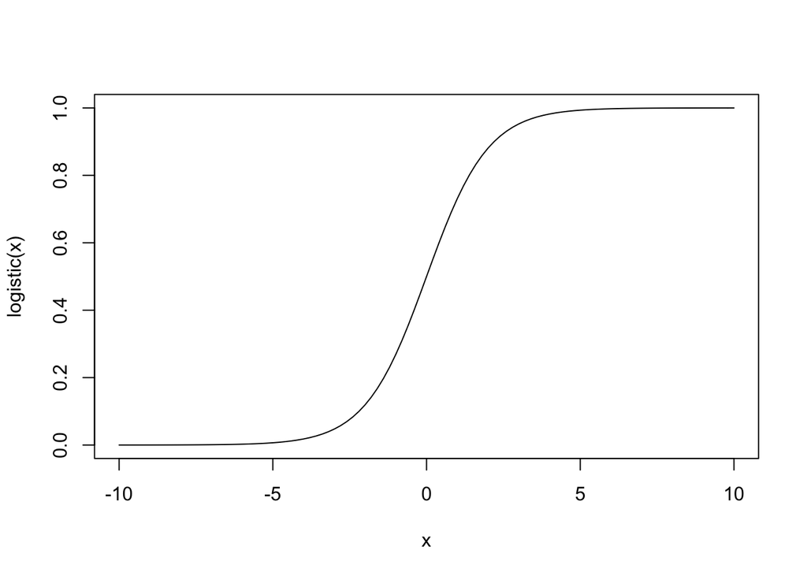

```r
logistic <- function(x) {
  1 / (1 + exp(1)^(-x) )
}

curve(logistic, from=-10, to=10)
```

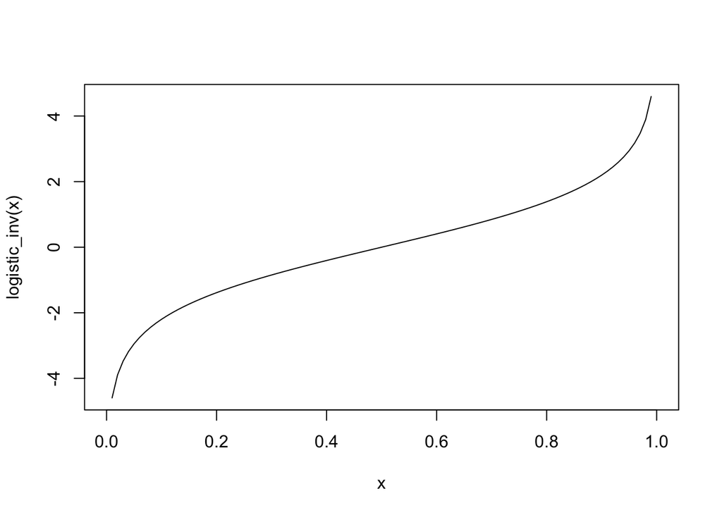

```r
logistic_inv <- function(y) {
  - (log((1-y)/y))
}

curve(logistic_inv, from=0, to=1)
```

**NOTE“** These functions are quite handy, in evaluating logistic regression results. You may want to save these functions in your own package.

```r
# DO NOT EDIT
c(-Inf,0,Inf) %>% logistic
```

```
## [1] 0.0 0.5 1.0
```

```r
c(0,0.5,1) %>% logistic_inv
```

```
## [1] -Inf    0  Inf
```

## German Credit Model

Using the GermanCredit data from the **Caret** package/ UCI Machine Learning Library, create a model for `Class` (“Good” vs. “Bad” ). Show your model performance.

```r
data(GermanCredit)

# hmmm... I'll write a Step_AIC wrapper again here because the FE problem above takes lm, while this will require glm.  I'll write a common one some other time.

stepAIC_fwd_bi_wrapper <- function(outcome_var_name, dataset) {
  bi_fit_simplest <- glm(eval(parse(text = outcome_var_name)) ~ 1, dataset, family="binomial")
  dataset %>% names %>% setdiff(outcome_var_name) %>% paste(collapse=" + ") -> predictors_only
  # put outcome back together with predictors in formula
  stepAIC_formula <- paste(outcome_var_name, "~", predictors_only)
  # stick formula into forward AIC
  stepAIC ( bi_fit_simplest, scope = stepAIC_formula, direction = "forward")
}



GermanCreditFwd <- stepAIC_fwd_bi_wrapper('Class', GermanCredit)
```

[output not shown]

[output cut: 1314 more lines]

[output not shown]

```r
stepAIC_bkwd_bi_wrapper <- function(outcome_var_name, dataset) {
  fit_full <- glm(Class ~ ., data=dataset, family="binomial")
  stepAIC(fit_full, scope = ~1, direction = "backward")
}



GermanCreditBkwd <- stepAIC_bkwd_bi_wrapper('Class', GermanCredit)
```

[output not shown]

[output cut: 1536 more lines]

[output not shown]

```r
# This calcuates a simple accuracy rate... correct / all observations

accuracy_rate <- function(y,yhat) {
  ifelse(y==yhat, 1, 0) %>% mean
}

good_or_bad <- function(yhat) {
  ifelse((logistic(yhat)>=.5), "Good", "Bad")
}



accuracy_rate(GermanCredit$Class, predict(GermanCreditFwd, GermanCredit) %>% good_or_bad)
```

```
## [1] 0.783
```

```r
accuracy_rate(GermanCredit$Class, predict(GermanCreditBkwd, GermanCredit) %>% good_or_bad)
```

```
## [1] 0.786
```

```r
# Again, the backward model is just a tiny bit better.  Our accuracy exceeds the baseline accuracy rate of 70 % on recommended by Kuhn p. 73.
```